# HT05

2023-03-17

# Hoja de Trabajo 05 - Naive Bayes

## 1 - Conjuntos de entrenamiento y pruebas pasadas

### Limpiando los datos

Columnas a utilizar (basándonos en el análisis exploratorio de la hoja anterior):

```r
print(paste(columns_used,collapse=' '))
```

```
## [1] "neighborhood houseStyle houseZone houseUtilities roadAccess remodelated roofStyle roofMaterial overallQuality overallCondition exteriorCondition foundationMaterial basement basementCondition fireplace garageArea pool additionalFeature livingArea yearBuilt salePrice saleType mSZoning"
```

Un 75% del dataset se usará para entrenar el árbol.

```r
set.seed(5)
expected_result <- clean_data$salePrice
partition <- createDataPartition(y=expected_result,
                                 p=.75,
                                 list=F)
train_set <- clean_data[partition,]
test_set <- clean_data[-partition,]
```

## 2 - Modelo de regresión usando bayes ingenuo

```r
colnames(test_set)
```

```
##  [1] "neighborhood"       "houseStyle"         "houseZone"
##  [4] "houseUtilities"     "roadAccess"         "remodelated"
##  [7] "roofStyle"          "roofMaterial"       "overallQuality"
## [10] "overallCondition"   "exteriorCondition"  "foundationMaterial"
## [13] "basement"           "basementCondition"  "fireplace"
## [16] "garageArea"         "pool"               "additionalFeature"
## [19] "livingArea"         "yearBuilt"          "salePrice"
## [22] "saleType"           "mSZoning"
```

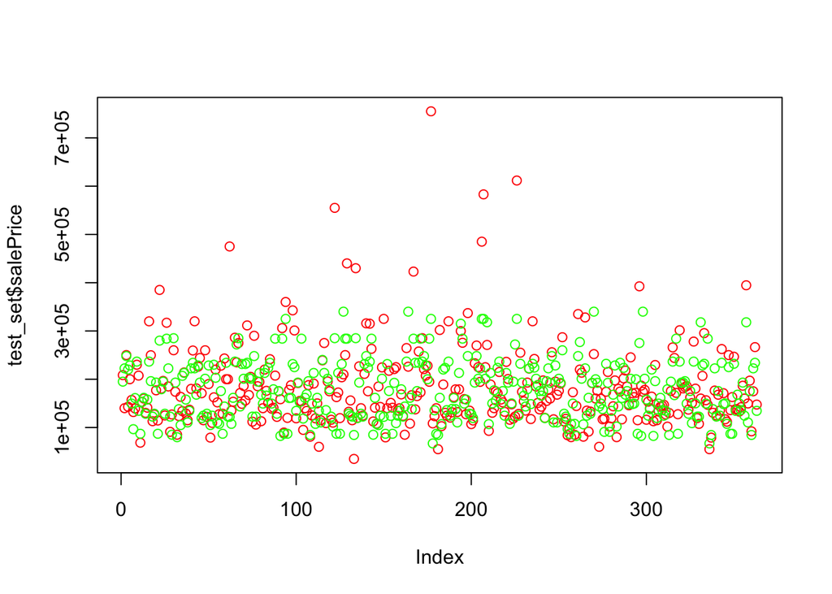

```r
model_naive_bayes <- naiveBayes(salePrice~., data=train_set)

pred_bayes <- predict(model_naive_bayes, newdata=test_set[,-21])
pred_bayes <- as.numeric(as.character(pred_bayes))
plot(test_set$salePrice, col="red")
points(pred_bayes, col="green")
```

```r
EMA <- mean(test_set$salePrice-pred_bayes, na.rm = T)
```

## 3 - Modelo de clasificacion, variable categórica que hizo con el precio de las casas (barata, media y cara)

Volviendo a usar la variable categorica

```r
test_set$economy <- ifelse(test_set$salePrice < 163000, "Economic", ifelse(test_set$salePrice >= 163000 & test_set$salePrice <= 214000, "Average", "Expensive"))
train_set$economy <- ifelse(train_set$salePrice < 163000, "Economic", ifelse(train_set$salePrice >= 163000 & train_set$salePrice <= 214000, "Average", "Expensive"))
```

Implementar modelo de clasificacion

```r
model_clasification <- naiveBayes(economy ~ ., data = train_set)
predictions_clasification <- predictions <- predict(model_clasification, newdata = test_set, type = "class")
confusion_matrix_clasification <- table(predictions_clasification, test_set$economy)
accuracy_clasification <- sum(diag(confusion_matrix_clasification)) / sum(confusion_matrix_clasification)
print(accuracy_clasification)
```

```
## [1] 0.6969697
```

Se obtuvo 0.6969697 de presicion, el cual indica que la clasificación es eficiente.

## 4 - Utilizar los modelos con el conjunto de prueba y determine la eficiencia del algoritmo

```r
clean_test = na.omit(test_set)

y4_cl <- clean_test[,c("economy")]
y4_cl <- as.numeric(as.factor(y4_cl))
y_pred_4_cl <- predict(model_clasification, newdata = clean_test)
y_pred_4_cl <- as.numeric(as.factor(y_pred_4_cl))
y4_mean_cl <- mean(y4_cl, na.rm = TRUE)
y_pred_4_mean_cl <- mean(y_pred_4_cl, na.rm = TRUE)
difference_cl <- abs(y4_mean_cl - y_pred_4_mean_cl)
```

Para el modelo de clasificación se obtuvo una diferencia de 0.4843305 entre el promedio de conjuntos de valores reales y predichos lo cual es bastante bajo lo que significa que la predicción se acerca bastante a los valores reales.

## 5 - Analizar los resultados del modelo de regresión

```r
y4_reg <- clean_test[,c("salePrice")]
y_pred_4_reg <- predict(model_naive_bayes, clean_test)
y_pred_4_reg <- as.numeric(y_pred_4_reg)
abs_error_4_reg <- abs(mean(y_pred_4_reg - clean_test$salePrice))
```

Para el modelo de regresión se obtuvo para un error absoluto de 1.833183^{5}.

## 6 - Comprar resultados del modelo de regresión lineal y el árbol de regresión

En base a los resultados de hojas de trabajo anteriores sabemos que el modelo de regresión lineal multivariable funcionó mejor, esto porque el r^2 era de 0.8231 lo que significa que el modelo se adapta bastante bien a la data mientras que con el árbol de regresión lineal se obtuvo un error absoluto de 1314.3656456, un RMSE de 4.5178048^{4} y en promedio hubo un error de USD 3040. Sin embargo, no se puede decir lo mismo del modelo univariable ya que se obtuvo un valor para r^2 de 0.5200 y no es un valor aceptable para poder hacer predicciones ya que no devuelve valores tan exactos.

## 7 - Realizar análisis de la eficiencia del modelo de clasificación usando una matriz de confusión.

```r
train_prediction <- predict(model_clasification, newdata = train_set)
test_prediction <- predict(model_clasification, newdata = test_set)
```

### Matriz de confusión para set de entrenamiento

```r
confusionMatrix(train_prediction, as.factor(train_set$economy))
```

```
## Confusion Matrix and Statistics
##
##            Reference
## Prediction  Average Economic Expensive
##   Average        29        0         1
##   Economic       41      508         2
##   Expensive     206       41       269
##
## Overall Statistics
##
##                Accuracy : 0.7347
##                  95% CI : (0.7075, 0.7607)
##     No Information Rate : 0.5005
##     P-Value [Acc > NIR] : < 2.2e-16
##
##                   Kappa : 0.5757
##
##  Mcnemar's Test P-Value : < 2.2e-16
##
## Statistics by Class:
##
##                      Class: Average Class: Economic Class: Expensive
## Sensitivity                 0.10507          0.9253           0.9890
## Specificity                 0.99878          0.9215           0.7006
## Pos Pred Value              0.96667          0.9220           0.5213
## Neg Pred Value              0.76851          0.9249           0.9948
## Prevalence                  0.25160          0.5005           0.2479
## Detection Rate              0.02644          0.4631           0.2452
## Detection Prevalence        0.02735          0.5023           0.4704
## Balanced Accuracy           0.55193          0.9234           0.8448
```

### Matriz de confusión para set de prueba

```r
confusionMatrix(test_prediction, as.factor(test_set$economy))
```

```
## Confusion Matrix and Statistics
##
##            Reference
## Prediction  Average Economic Expensive
##   Average         9        0         0
##   Economic       16      158         4
##   Expensive      69       21        86
##
## Overall Statistics
##
##                Accuracy : 0.697
##                  95% CI : (0.6468, 0.7438)
##     No Information Rate : 0.4931
##     P-Value [Acc > NIR] : 2.831e-15
##
##                   Kappa : 0.5202
##
##  Mcnemar's Test P-Value : < 2.2e-16
##
## Statistics by Class:
##
##                      Class: Average Class: Economic Class: Expensive
## Sensitivity                 0.09574          0.8827           0.9556
## Specificity                 1.00000          0.8913           0.6703
## Pos Pred Value              1.00000          0.8876           0.4886
## Neg Pred Value              0.75989          0.8865           0.9786
## Prevalence                  0.25895          0.4931           0.2479
## Detection Rate              0.02479          0.4353           0.2369
## Detection Prevalence        0.02479          0.4904           0.4848
## Balanced Accuracy           0.54787          0.8870           0.8129
```

Para la matriz de confusión de entrenamiento se obtuvo una eficiencia aceptable mientras que para el conjunto de prueba la eficiencia disminuypo levemente.

## 8 - Analizar el modelo ¿cree que pueda estar sobre ajustado?

```r
train_prediction <- predict(model_clasification, newdata = train_set)
test_prediction <- predict(model_clasification, newdata = test_set)
```

### Matriz de confusión para set de entrenamiento

```r
confusionMatrix(train_prediction, as.factor(train_set$economy))
```

```
## Confusion Matrix and Statistics
##
##            Reference
## Prediction  Average Economic Expensive
##   Average        29        0         1
##   Economic       41      508         2
##   Expensive     206       41       269
##
## Overall Statistics
##
##                Accuracy : 0.7347
##                  95% CI : (0.7075, 0.7607)
##     No Information Rate : 0.5005
##     P-Value [Acc > NIR] : < 2.2e-16
##
##                   Kappa : 0.5757
##
##  Mcnemar's Test P-Value : < 2.2e-16
##
## Statistics by Class:
##
##                      Class: Average Class: Economic Class: Expensive
## Sensitivity                 0.10507          0.9253           0.9890
## Specificity                 0.99878          0.9215           0.7006
## Pos Pred Value              0.96667          0.9220           0.5213
## Neg Pred Value              0.76851          0.9249           0.9948
## Prevalence                  0.25160          0.5005           0.2479
## Detection Rate              0.02644          0.4631           0.2452
## Detection Prevalence        0.02735          0.5023           0.4704
## Balanced Accuracy           0.55193          0.9234           0.8448
```

### Matriz de confusión para set de prueba

```r
confusionMatrix(test_prediction, as.factor(test_set$economy))
```

```
## Confusion Matrix and Statistics
##
##            Reference
## Prediction  Average Economic Expensive
##   Average         9        0         0
##   Economic       16      158         4
##   Expensive      69       21        86
##
## Overall Statistics
##
##                Accuracy : 0.697
##                  95% CI : (0.6468, 0.7438)
##     No Information Rate : 0.4931
##     P-Value [Acc > NIR] : 2.831e-15
##
##                   Kappa : 0.5202
##
##  Mcnemar's Test P-Value : < 2.2e-16
##
## Statistics by Class:
##
##                      Class: Average Class: Economic Class: Expensive
## Sensitivity                 0.09574          0.8827           0.9556
## Specificity                 1.00000          0.8913           0.6703
## Pos Pred Value              1.00000          0.8876           0.4886
## Neg Pred Value              0.75989          0.8865           0.9786
## Prevalence                  0.25895          0.4931           0.2479
## Detection Rate              0.02479          0.4353           0.2369
## Detection Prevalence        0.02479          0.4904           0.4848
## Balanced Accuracy           0.54787          0.8870           0.8129
```

La accuracy del modelo en el set de prueba es de 0.697 y de 0.73 para el set de entrenamiento. No es mucha la diferencia entre los dos conjuntos de datos. Por lo que podemos descartar que el modelo tenga sobre ajuste.

## 9 - Haga un modelo usando validación cruzada

```r
fit_control <- trainControl(method = "cv", number = 2)
cross_model <- train(economy ~ ., data = na.omit(train_set), method = "nb", trControl = fit_control)
```

Realizando predicciones

```r
predictions_cross_model <-  predict(cross_model, newdata = test_set)
confusionMatrix(predictions_cross_model, as.factor(na.omit(test_set)$economy))
```

```
## Confusion Matrix and Statistics
##
##            Reference
## Prediction  Average Economic Expensive
##   Average        89       19        18
##   Economic        4      150         1
##   Expensive       0        1        69
##
## Overall Statistics
##
##                Accuracy : 0.8775
##                  95% CI : (0.8385, 0.9099)
##     No Information Rate : 0.4843
##     P-Value [Acc > NIR] : < 2.2e-16
##
##                   Kappa : 0.8089
##
##  Mcnemar's Test P-Value : 4.034e-06
##
## Statistics by Class:
##
##                      Class: Average Class: Economic Class: Expensive
## Sensitivity                  0.9570          0.8824           0.7841
## Specificity                  0.8566          0.9724           0.9962
## Pos Pred Value               0.7063          0.9677           0.9857
## Neg Pred Value               0.9822          0.8980           0.9324
## Prevalence                   0.2650          0.4843           0.2507
## Detection Rate               0.2536          0.4274           0.1966
## Detection Prevalence         0.3590          0.4416           0.1994
## Balanced Accuracy            0.9068          0.9274           0.8901
```

## 10 - Compare la eficiencia del algoritmo con el resultado obtenido con el árbol de decisión (el de clasificación) y el modelo de random forest que hizo en la hoja pasada. ¿Cuál es mejor para predecir? ¿Cuál se demoró más en procesar?

Tomando en cuenta la matriz de confusión, tenemos una exactitud de 0.8775, mientras que para la hoja anterior utilizando el método de Random Forest se tuvo 0.849. Por lo que este algoritmo es más eficiente para clasificar los valores. Sin embargo, el costo es el tiempo que utiliza dado que con Random Forest el modelo se entrenó más rápido.